# Clustering

### Description of the dataset

```r
date()
```

```
## [1] "Sat Nov 27 16:29:05 2021"
```

```r
# access the MASS package
install.packages("corrplot",
                 repos = "https://cran.rstudio.com/bin/windows/contrib/4.1/corrplot_0.92.zip")
library(MASS)
library(GGally)
library(ggplot2)
library(corrplot)
library(tidyverse)
library(cowplot)

# load the data
data("Boston")
data <- Boston
# explore the dataset
str(data)
```

```
## 'data.frame':    506 obs. of  14 variables:
##  $ crim   : num  0.00632 0.02731 0.02729 0.03237 0.06905 ...
##  $ zn     : num  18 0 0 0 0 0 12.5 12.5 12.5 12.5 ...
##  $ indus  : num  2.31 7.07 7.07 2.18 2.18 2.18 7.87 7.87 7.87 7.87 ...
##  $ chas   : int  0 0 0 0 0 0 0 0 0 0 ...
##  $ nox    : num  0.538 0.469 0.469 0.458 0.458 0.458 0.524 0.524 0.524 0.524 ...
##  $ rm     : num  6.58 6.42 7.18 7 7.15 ...
##  $ age    : num  65.2 78.9 61.1 45.8 54.2 58.7 66.6 96.1 100 85.9 ...
##  $ dis    : num  4.09 4.97 4.97 6.06 6.06 ...
##  $ rad    : int  1 2 2 3 3 3 5 5 5 5 ...
##  $ tax    : num  296 242 242 222 222 222 311 311 311 311 ...
##  $ ptratio: num  15.3 17.8 17.8 18.7 18.7 18.7 15.2 15.2 15.2 15.2 ...
##  $ black  : num  397 397 393 395 397 ...
##  $ lstat  : num  4.98 9.14 4.03 2.94 5.33 ...
##  $ medv   : num  24 21.6 34.7 33.4 36.2 28.7 22.9 27.1 16.5 18.9 ...
```

Data has one integer (rad), one dichotomous (chas) and the rest are numeric variables.  
Name of the dataset is “Housing Values in Suburbs of Boston”. Dataset has 506 observations and 14 variables. It describes housing Values in Suburbs of Boston.  
This data frame contains the following columns:

crim - per capita crime rate by town.  
zn - proportion of residential land zoned for lots over 25,000 sq.ft.  
indus - proportion of non-retail business acres per town.  
chas - Charles River dummy variable (= 1 if tract bounds river; 0 otherwise).  
nox - nitrogen oxides concentration (parts per 10 million).  
rm - average number of rooms per dwelling.  
age - proportion of owner-occupied units built prior to 1940.  
dis - weighted mean of distances to five Boston employment centres.  
rad - index of accessibility to radial highways.  
tax - full-value property-tax rate per $10,000.  
ptratio - pupil-teacher ratio by town.  
black - 1000(Bk - 0.63)^2 where Bk is the proportion of blacks by town.  
lstat - lower status of the population (percent).  
medv - median value of owner-occupied homes in $1000s.

Sources of the dataset:  
1) Harrison, D. and Rubinfeld, D.L. (1978) Hedonic prices and the demand for clean air. J. Environ. Economics and Management 5, 81–102.  
2) Belsley D.A., Kuh, E. and Welsch, R.E. (1980) Regression Diagnostics. Identifying Influential Data and Sources of Collinearity. New York: Wiley.

More information about the variables in the Boston dataset can be found by the following link: https://stat.ethz.ch/R-manual/R-devel/library/MASS/html/Boston.html.  
### Overview of the data

```r
summary(data)
```

```
##       crim                zn             indus            chas
##  Min.   : 0.00632   Min.   :  0.00   Min.   : 0.46   Min.   :0.00000
##  1st Qu.: 0.08205   1st Qu.:  0.00   1st Qu.: 5.19   1st Qu.:0.00000
##  Median : 0.25651   Median :  0.00   Median : 9.69   Median :0.00000
##  Mean   : 3.61352   Mean   : 11.36   Mean   :11.14   Mean   :0.06917
##  3rd Qu.: 3.67708   3rd Qu.: 12.50   3rd Qu.:18.10   3rd Qu.:0.00000
##  Max.   :88.97620   Max.   :100.00   Max.   :27.74   Max.   :1.00000
##       nox               rm             age              dis
##  Min.   :0.3850   Min.   :3.561   Min.   :  2.90   Min.   : 1.130
##  1st Qu.:0.4490   1st Qu.:5.886   1st Qu.: 45.02   1st Qu.: 2.100
##  Median :0.5380   Median :6.208   Median : 77.50   Median : 3.207
##  Mean   :0.5547   Mean   :6.285   Mean   : 68.57   Mean   : 3.795
##  3rd Qu.:0.6240   3rd Qu.:6.623   3rd Qu.: 94.08   3rd Qu.: 5.188
##  Max.   :0.8710   Max.   :8.780   Max.   :100.00   Max.   :12.127
##       rad              tax           ptratio          black
##  Min.   : 1.000   Min.   :187.0   Min.   :12.60   Min.   :  0.32
##  1st Qu.: 4.000   1st Qu.:279.0   1st Qu.:17.40   1st Qu.:375.38
##  Median : 5.000   Median :330.0   Median :19.05   Median :391.44
##  Mean   : 9.549   Mean   :408.2   Mean   :18.46   Mean   :356.67
##  3rd Qu.:24.000   3rd Qu.:666.0   3rd Qu.:20.20   3rd Qu.:396.23
##  Max.   :24.000   Max.   :711.0   Max.   :22.00   Max.   :396.90
##      lstat            medv
##  Min.   : 1.73   Min.   : 5.00
##  1st Qu.: 6.95   1st Qu.:17.02
##  Median :11.36   Median :21.20
##  Mean   :12.65   Mean   :22.53
##  3rd Qu.:16.95   3rd Qu.:25.00
##  Max.   :37.97   Max.   :50.00
```

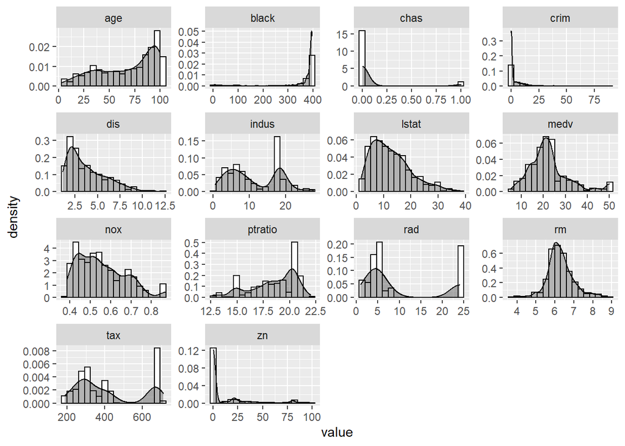

```r
# plot matrix of the variables

### ggpairs(data, mapping = aes(), lower = list(combo = wrap("facethist", bins = 20)))
# it was suggested on DataCamp but I don`t seeing necessity in this, since the plots are small and hardly interpretative, moreover, I will have correlation plot separately for the dataset.

# Other than matrix plot, I will look at the distribution separately.
gather(data) %>% ggplot(aes(x = value))  + geom_histogram(aes(y = ..density..), colour="black", fill="white", bins = 18,) +  geom_density(alpha = 0.3, fill = "black") + facet_wrap("key", scales = "free")
```

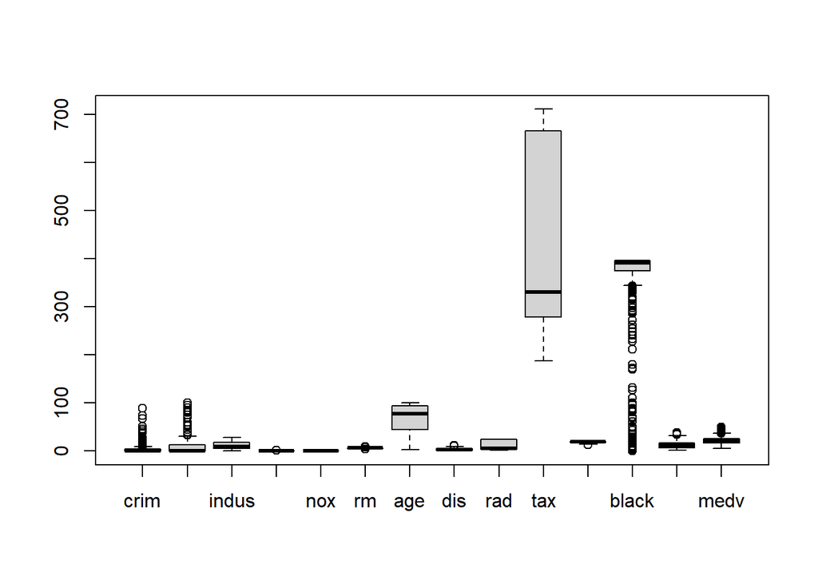

```r
boxplot(data)
```

Below we can see correlation table for the variables.

```r
# calculate the correlation matrix and round it
cor_matrix<-cor(data) %>% round(digits = 2)

# print the correlation matrix
cor_matrix
```

```
##          crim    zn indus  chas   nox    rm   age   dis   rad   tax ptratio
## crim     1.00 -0.20  0.41 -0.06  0.42 -0.22  0.35 -0.38  0.63  0.58    0.29
## zn      -0.20  1.00 -0.53 -0.04 -0.52  0.31 -0.57  0.66 -0.31 -0.31   -0.39
## indus    0.41 -0.53  1.00  0.06  0.76 -0.39  0.64 -0.71  0.60  0.72    0.38
## chas    -0.06 -0.04  0.06  1.00  0.09  0.09  0.09 -0.10 -0.01 -0.04   -0.12
## nox      0.42 -0.52  0.76  0.09  1.00 -0.30  0.73 -0.77  0.61  0.67    0.19
## rm      -0.22  0.31 -0.39  0.09 -0.30  1.00 -0.24  0.21 -0.21 -0.29   -0.36
## age      0.35 -0.57  0.64  0.09  0.73 -0.24  1.00 -0.75  0.46  0.51    0.26
## dis     -0.38  0.66 -0.71 -0.10 -0.77  0.21 -0.75  1.00 -0.49 -0.53   -0.23
## rad      0.63 -0.31  0.60 -0.01  0.61 -0.21  0.46 -0.49  1.00  0.91    0.46
## tax      0.58 -0.31  0.72 -0.04  0.67 -0.29  0.51 -0.53  0.91  1.00    0.46
## ptratio  0.29 -0.39  0.38 -0.12  0.19 -0.36  0.26 -0.23  0.46  0.46    1.00
## black   -0.39  0.18 -0.36  0.05 -0.38  0.13 -0.27  0.29 -0.44 -0.44   -0.18
## lstat    0.46 -0.41  0.60 -0.05  0.59 -0.61  0.60 -0.50  0.49  0.54    0.37
## medv    -0.39  0.36 -0.48  0.18 -0.43  0.70 -0.38  0.25 -0.38 -0.47   -0.51
##         black lstat  medv
## crim    -0.39  0.46 -0.39
## zn       0.18 -0.41  0.36
## indus   -0.36  0.60 -0.48
## chas     0.05 -0.05  0.18
## nox     -0.38  0.59 -0.43
## rm       0.13 -0.61  0.70
## age     -0.27  0.60 -0.38
## dis      0.29 -0.50  0.25
## rad     -0.44  0.49 -0.38
## tax     -0.44  0.54 -0.47
## ptratio -0.18  0.37 -0.51
## black    1.00 -0.37  0.33
## lstat   -0.37  1.00 -0.74
## medv     0.33 -0.74  1.00
```

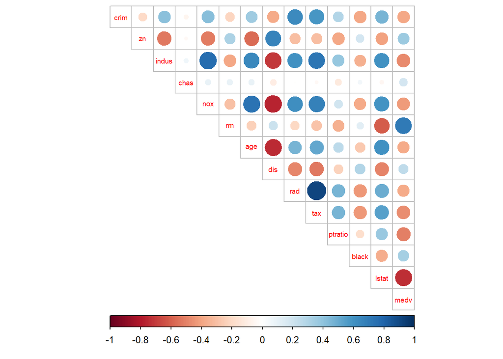

```r
# visualize the correlation matrix
corrplot(cor_matrix, method="circle", type="upper" , cl.pos="b" , tl.pos="d", tl.cex = 0.6)
```

There is strong correlation between nox and indus (r = 0.760) indicating that the higher the nitrogen oxides concentration, the higher the proportion of non-retail business acres per town;  
Nox and age (r= 0.730) indicationg that the older the age of the buildings, the higher the nitrogen oxides concentration;  
Nox and dis (r= -0.770) indicationg that the longer the distance from the Boston employment centres, the lower the nitrogen oxides concentration and the proportion of non-retail business acres per town;

Age and dis (r = -0.750) indicating that the longer the distance from the Boston employment centres, the lower the age of the buildings;

Tax and indus (r = 0.720) meaning that the higher the full-value property-tax rate, the bigger the proportion of non-retail business acres per town;  
Tax and rad (r= 0.910) indicationg that the higher the full-value property-tax rate, the better the accessibility to radial highways;

Medv and rm (r = 0.700) indicating that the higher the median value of owner-occupied homes, the higher the average number of rooms per dwelling;  
Medv and lstat (r= -0.740) meaning that the higher the median value of owner-occupied homes, the lower the proportion of the lower status population.

### Standartization of the dataset

```r
# center and standardize variables
data_scaled <- scale(data)

# summaries of the scaled variables
summary(data_scaled)
```

```
##       crim                 zn               indus              chas
##  Min.   :-0.419367   Min.   :-0.48724   Min.   :-1.5563   Min.   :-0.2723
##  1st Qu.:-0.410563   1st Qu.:-0.48724   1st Qu.:-0.8668   1st Qu.:-0.2723
##  Median :-0.390280   Median :-0.48724   Median :-0.2109   Median :-0.2723
##  Mean   : 0.000000   Mean   : 0.00000   Mean   : 0.0000   Mean   : 0.0000
##  3rd Qu.: 0.007389   3rd Qu.: 0.04872   3rd Qu.: 1.0150   3rd Qu.:-0.2723
##  Max.   : 9.924110   Max.   : 3.80047   Max.   : 2.4202   Max.   : 3.6648
##       nox                rm               age               dis
##  Min.   :-1.4644   Min.   :-3.8764   Min.   :-2.3331   Min.   :-1.2658
##  1st Qu.:-0.9121   1st Qu.:-0.5681   1st Qu.:-0.8366   1st Qu.:-0.8049
##  Median :-0.1441   Median :-0.1084   Median : 0.3171   Median :-0.2790
##  Mean   : 0.0000   Mean   : 0.0000   Mean   : 0.0000   Mean   : 0.0000
##  3rd Qu.: 0.5981   3rd Qu.: 0.4823   3rd Qu.: 0.9059   3rd Qu.: 0.6617
##  Max.   : 2.7296   Max.   : 3.5515   Max.   : 1.1164   Max.   : 3.9566
##       rad               tax             ptratio            black
##  Min.   :-0.9819   Min.   :-1.3127   Min.   :-2.7047   Min.   :-3.9033
##  1st Qu.:-0.6373   1st Qu.:-0.7668   1st Qu.:-0.4876   1st Qu.: 0.2049
##  Median :-0.5225   Median :-0.4642   Median : 0.2746   Median : 0.3808
##  Mean   : 0.0000   Mean   : 0.0000   Mean   : 0.0000   Mean   : 0.0000
##  3rd Qu.: 1.6596   3rd Qu.: 1.5294   3rd Qu.: 0.8058   3rd Qu.: 0.4332
##  Max.   : 1.6596   Max.   : 1.7964   Max.   : 1.6372   Max.   : 0.4406
##      lstat              medv
##  Min.   :-1.5296   Min.   :-1.9063
##  1st Qu.:-0.7986   1st Qu.:-0.5989
##  Median :-0.1811   Median :-0.1449
##  Mean   : 0.0000   Mean   : 0.0000
##  3rd Qu.: 0.6024   3rd Qu.: 0.2683
##  Max.   : 3.5453   Max.   : 2.9865
```

```r
# class of the boston_scaled object
class(data_scaled)
```

```
## [1] "matrix" "array"
```

```r
# change the object to data frame
data_scaled <- as.data.frame(data_scaled)
data_scaled_k <- as.data.frame(data_scaled)
```

After scaling we made that each variable has mean 0. The next step, it to categorize the crim using quantities as break points.

```r
# create a quantile vector of crim and print it
bins <- quantile(data_scaled$crim)

# create a categorical variable 'crime'
crime <- cut(data_scaled$crim, breaks = bins, include.lowest = TRUE, label = c("low", "med_low", "med_high", "high"))

# look at the table of the new factor crime
table(crime)
```

```
## crime
##      low  med_low med_high     high
##      127      126      126      127
```

```r
# remove original crim from the dataset
data_scaled <- dplyr::select(data_scaled, -crim)

# add the new categorical value to scaled data
data_scaled <- data.frame(data_scaled, crime)
str(data_scaled)
```

```
## 'data.frame':    506 obs. of  14 variables:
##  $ zn     : num  0.285 -0.487 -0.487 -0.487 -0.487 ...
##  $ indus  : num  -1.287 -0.593 -0.593 -1.306 -1.306 ...
##  $ chas   : num  -0.272 -0.272 -0.272 -0.272 -0.272 ...
##  $ nox    : num  -0.144 -0.74 -0.74 -0.834 -0.834 ...
##  $ rm     : num  0.413 0.194 1.281 1.015 1.227 ...
##  $ age    : num  -0.12 0.367 -0.266 -0.809 -0.511 ...
##  $ dis    : num  0.14 0.557 0.557 1.077 1.077 ...
##  $ rad    : num  -0.982 -0.867 -0.867 -0.752 -0.752 ...
##  $ tax    : num  -0.666 -0.986 -0.986 -1.105 -1.105 ...
##  $ ptratio: num  -1.458 -0.303 -0.303 0.113 0.113 ...
##  $ black  : num  0.441 0.441 0.396 0.416 0.441 ...
##  $ lstat  : num  -1.074 -0.492 -1.208 -1.36 -1.025 ...
##  $ medv   : num  0.16 -0.101 1.323 1.182 1.486 ...
##  $ crime  : Factor w/ 4 levels "low","med_low",..: 1 1 1 1 1 1 2 2 2 2 ...
```

We added a new column “crime” with categorized continuous “crim”. Next, I will devide dataset to train and drop sets (train set <-80% of dataset).

```r
# number of rows in the Boston dataset
n <- nrow(data_scaled)

# choose randomly 80% of the rows
ind <- sample(n,  size = n * 0.8)

# create train set
train <- data_scaled[ind,]

# create test set
test <- data_scaled[-ind,]
```

Now we have two datasets for analysis and tasting.

## Linear Discriminant analysis

```r
# linear discriminant analysis
lda.fit <- lda(crime ~., data = train)

# print the lda.fit object
lda.fit
```

```
## Call:
## lda(crime ~ ., data = train)
##
## Prior probabilities of groups:
##       low   med_low  med_high      high
## 0.2524752 0.2475248 0.2475248 0.2524752
##
## Group means:
##                  zn      indus        chas        nox          rm        age
## low       1.0910168 -0.9355281 -0.07933396 -0.9004590  0.52182063 -0.8985283
## med_low  -0.1307168 -0.2678694 -0.07547406 -0.5640091 -0.15398768 -0.3204002
## med_high -0.4014859  0.1793525  0.20012296  0.4553504  0.05161504  0.4814084
## high     -0.4872402  1.0149946 -0.07933396  1.0511511 -0.45606389  0.8002135
##                 dis        rad        tax      ptratio       black       lstat
## low       0.8484928 -0.6857469 -0.7634433 -0.492990836  0.37536299 -0.78211370
## med_low   0.3489941 -0.5580869 -0.4862855  0.002524961  0.32052918 -0.10629558
## med_high -0.4270021 -0.4271616 -0.3040111 -0.335589782  0.07019309  0.03617624
## high     -0.8682133  1.6596029  1.5294129  0.805778429 -0.89887487  0.93539061
##                 medv
## low       0.62003080
## med_low  -0.02259476
## med_high  0.13789054
## high     -0.70359556
##
## Coefficients of linear discriminants:
##                  LD1         LD2         LD3
## zn       0.106672784  0.75435838 -1.00566424
## indus    0.056552942 -0.06526858  0.35354761
## chas    -0.090008345 -0.02870262  0.03954967
## nox      0.189862671 -0.88439088 -1.27033045
## rm      -0.155437457 -0.04627015 -0.14174154
## age      0.319643057 -0.40393587 -0.23579351
## dis     -0.119302802 -0.34472237  0.33568382
## rad      3.747405845  1.06030460 -0.10323377
## tax      0.005007803 -0.18805429  0.56277170
## ptratio  0.120108191  0.02885459 -0.17722256
## black   -0.155784123  0.01766558  0.12512743
## lstat    0.111550411 -0.07629396  0.37484605
## medv     0.170547306 -0.25807454 -0.11389253
##
## Proportion of trace:
##    LD1    LD2    LD3
## 0.9512 0.0358 0.0130
```

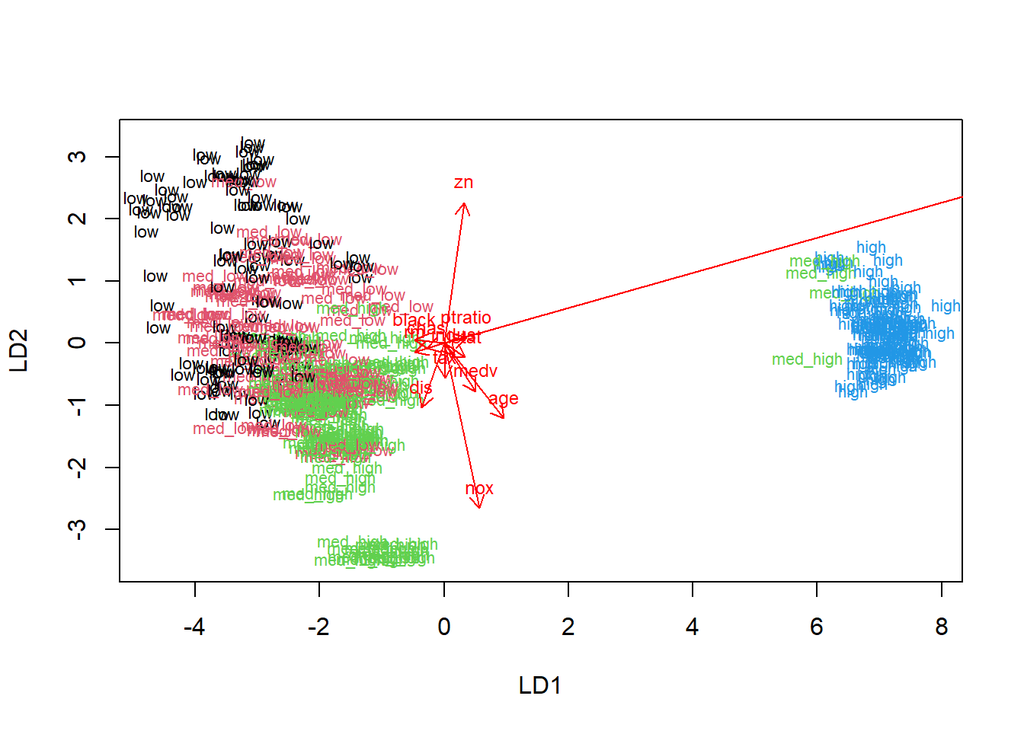

```r
# the function for lda biplot arrows
lda.arrows <- function(x, myscale = 1, arrow_heads = 0.1, color = "red", tex = 0.75, choices = c(1,2)){
  heads <- coef(x)
  arrows(x0 = 0, y0 = 0,
         x1 = myscale * heads[,choices[1]],
         y1 = myscale * heads[,choices[2]], col=color, length = arrow_heads)
  text(myscale * heads[,choices], labels = row.names(heads),
       cex = tex, col=color, pos=3)
}

# target classes as numeric
classes <- as.numeric(train$crime)

# plot the lda results
plot(lda.fit, dimen = 2, col = classes, pch = classes)
lda.arrows(lda.fit, myscale = 3)
```

```r
# save and remove crime categories
test_correct = test$crim
test$crim = NULL
```

### Prediction

```r
# predict classes with test data
lda.pred <- predict(lda.fit, newdata = test)

# cross tabulate the results
table(correct = test_correct, predicted = lda.pred$class)
```

```
##           predicted
## correct    low med_low med_high high
##   low       10      13        2    0
##   med_low    7      13        6    0
##   med_high   1       8       15    2
##   high       0       0        1   24
```

### K means

I saved scaled data before, so I will just use it now without repeating the procedure.

```r
summary(data_scaled_k)
```

```
##       crim                 zn               indus              chas
##  Min.   :-0.419367   Min.   :-0.48724   Min.   :-1.5563   Min.   :-0.2723
##  1st Qu.:-0.410563   1st Qu.:-0.48724   1st Qu.:-0.8668   1st Qu.:-0.2723
##  Median :-0.390280   Median :-0.48724   Median :-0.2109   Median :-0.2723
##  Mean   : 0.000000   Mean   : 0.00000   Mean   : 0.0000   Mean   : 0.0000
##  3rd Qu.: 0.007389   3rd Qu.: 0.04872   3rd Qu.: 1.0150   3rd Qu.:-0.2723
##  Max.   : 9.924110   Max.   : 3.80047   Max.   : 2.4202   Max.   : 3.6648
##       nox                rm               age               dis
##  Min.   :-1.4644   Min.   :-3.8764   Min.   :-2.3331   Min.   :-1.2658
##  1st Qu.:-0.9121   1st Qu.:-0.5681   1st Qu.:-0.8366   1st Qu.:-0.8049
##  Median :-0.1441   Median :-0.1084   Median : 0.3171   Median :-0.2790
##  Mean   : 0.0000   Mean   : 0.0000   Mean   : 0.0000   Mean   : 0.0000
##  3rd Qu.: 0.5981   3rd Qu.: 0.4823   3rd Qu.: 0.9059   3rd Qu.: 0.6617
##  Max.   : 2.7296   Max.   : 3.5515   Max.   : 1.1164   Max.   : 3.9566
##       rad               tax             ptratio            black
##  Min.   :-0.9819   Min.   :-1.3127   Min.   :-2.7047   Min.   :-3.9033
##  1st Qu.:-0.6373   1st Qu.:-0.7668   1st Qu.:-0.4876   1st Qu.: 0.2049
##  Median :-0.5225   Median :-0.4642   Median : 0.2746   Median : 0.3808
##  Mean   : 0.0000   Mean   : 0.0000   Mean   : 0.0000   Mean   : 0.0000
##  3rd Qu.: 1.6596   3rd Qu.: 1.5294   3rd Qu.: 0.8058   3rd Qu.: 0.4332
##  Max.   : 1.6596   Max.   : 1.7964   Max.   : 1.6372   Max.   : 0.4406
##      lstat              medv
##  Min.   :-1.5296   Min.   :-1.9063
##  1st Qu.:-0.7986   1st Qu.:-0.5989
##  Median :-0.1811   Median :-0.1449
##  Mean   : 0.0000   Mean   : 0.0000
##  3rd Qu.: 0.6024   3rd Qu.: 0.2683
##  Max.   : 3.5453   Max.   : 2.9865
```

```r
# euclidean distance matrix
dist_eu <- dist(data_scaled_k)

# look at the summary of the distances
summary(dist_eu)
```

```
##    Min. 1st Qu.  Median    Mean 3rd Qu.    Max.
##  0.1343  3.4625  4.8241  4.9111  6.1863 14.3970
```

```r
# manhattan distance matrix
dist_man <- dist(data_scaled_k, method = 'manhattan')

# look at the summary of the distances
summary(dist_man)
```

```
##    Min. 1st Qu.  Median    Mean 3rd Qu.    Max.
##  0.2662  8.4832 12.6090 13.5488 17.7568 48.8618
```

No we can see distances and its summary between the obseravtions. Next, we will run K-means clustering.

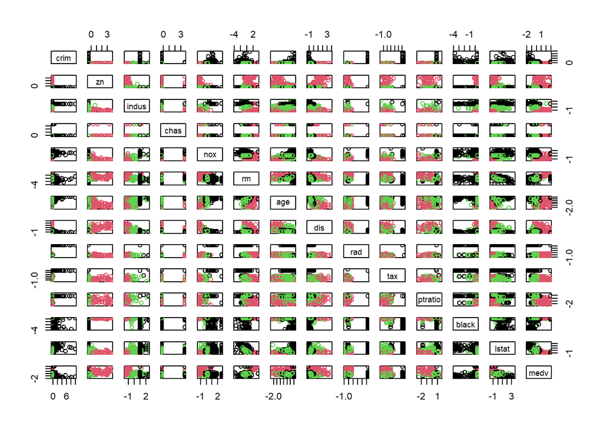

```r
km <- kmeans(na.omit(data_scaled_k), 3)

# plot the data_scaled_k dataset with clusters
pairs(data_scaled_k, col = km$cluster)
```

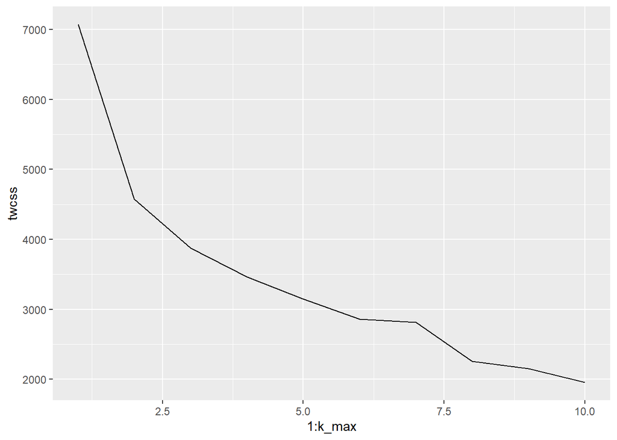

```r
# data_scaled_k dataset is available
set.seed(123)

# determine the number of clusters
k_max <- 10

# calculate the total within sum of squares
twcss <- sapply(1:k_max, function(k){kmeans(data_scaled_k, k)$tot.withinss})

# visualize the results
qplot(x = 1:k_max, y = twcss, geom = 'line')
```

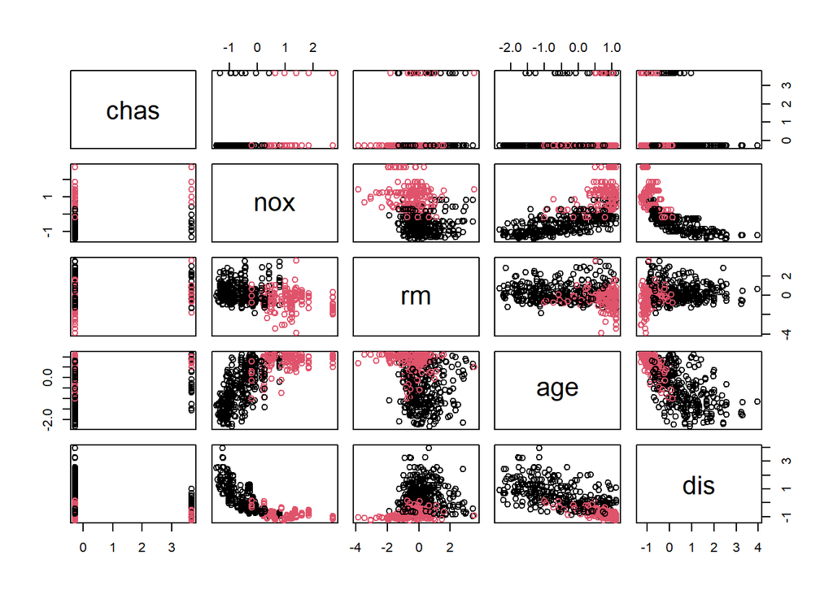

```r
# k-means clustering
km <-kmeans(data_scaled_k, centers = 2)

# plot the data_scaled_k dataset with clusters
pairs(data_scaled_k[4:8], col = km$cluster)
```

We can see that two clusters are good match, there are no outliners that would require one more cluster.